# Summary plotting of metaBEAT output

# This markdown notebook outlines step by step the processing of metaBEAT output data to produce the figures using in Kitson *et al.* (2017)

# Part 1: Minimum cluster depth analysis

We need to see how the number of clusters retained and read depth per well changes with different minimum cluster sizes. We want to end up in a situation where we are retaining only the most common unique sequences as these are likely to be the real biological systems. We will ideally also avoid clustering with thresholds lower than 100% as this can pull in rare sequencing errors and result in a centroid that is not in fact a genuine biological sequence. We have already iterated across minimum cluster sizes in the [Jupyter notebook](https://github.com/HullUni-bioinformatics/Kitson_et_al_NMB/blob/master/Jupyter_notebook/OPM_NMB_main_analysis.ipynb) so now we will use this data to help us choose a minimum cluster size.

### First of all read in all the libraries we’ll need to process the data

```r
### Clear the workspace
rm(list=ls())
### Load the libraries
library(reshape2)
library(ggplot2)
library(gridExtra)
library(grid)
library(scales)
library(RColorBrewer)
library(gtable)
```

### Plotting clusters retained and read depth against minimum cluster size - **all samples**

The aim of these plots is to look for a region of minimum cluster sizes that result in stable values for clusters retained or per well read depth and then choose the **minimum** stable value to maximise clusters retained. The assumption underlying this is that once we reach a stable set of parameter values we are looking at the real data *i.e.* any clusters retained in the stable region of minimum cluster size represent genuine biological sequences and not rare sequencing/PCR error.

```r
### Read in the data and look at the number of clusters and read depth against minimum cluster size
read.stats<-read.csv(file="data/Richard_combined_read_stats_all.csv", stringsAsFactors=FALSE, header=TRUE)
### Create a plot of number clusters in PCR wells by minimum cluster size
all.clusters<-ggplot(data = read.stats, aes(x=as.factor(clusters_min_cov), y=cluster_above_thres)) +
  geom_boxplot() +
  labs(y = "Clusters retained (all PCR wells)", x="Minimum cluster coverage") +
### make the labels more visible
  theme(axis.text = element_text(size = rel(1.2)),
         axis.title = element_text(size = rel(1.2)))
### Create a plot of read depth in PCR wells by minimum cluster size
all.reads<-ggplot(data = read.stats, aes(x=as.factor(clusters_min_cov), y=queries)) +
  geom_boxplot() +
  labs(y = "Per well read depth (all PCR wells)", x="Minimum cluster coverage") +
### make the labels more visible
  theme(axis.text = element_text(size = rel(1.2)),
         axis.title = element_text(size = rel(1.2)))
```

### Plotting clusters retained and read depth against minimum cluster size - **just negatives**

We should process the data a bit more so we can examine just negative controls as these give an indication of any possible background noise/contamination present in all NGS sequencing runs.

```r
### greedy regex to split the sample string by the underscore and leave us with a column for nest and a column for indentifier
read.stats<-cbind(read.stats, do.call(rbind, strsplit(as.character(read.stats$sample), "_|_.*_")))
### rename the last column as type
colnames(read.stats)[ncol(read.stats)]<-'template'
### process the last column into a sample type factor using a horrible ifelse statement
read.stats$type<-ifelse(read.stats$template=="PCRneg","Negative",
                          ifelse(read.stats$template=="eneg","Negative",
                            ifelse(read.stats$template=="DNAp","DNApositive",
                              ifelse(read.stats$template=="PCRp","PCRpositive","Sample"))))
### make the type column a factor
read.stats$type<-as.factor(read.stats$type)
### drop the columns, we don't need
#read.stats<-read.stats[,c(1:(ncol(read.stats)-3),ncol(read.stats))]
### Create a plot of number clusters in negative wells by minimum cluster size
neg.clusters<-ggplot(data = subset(read.stats, type=="Negative"), aes(x=as.factor(clusters_min_cov), y=cluster_above_thres)) +
  geom_boxplot() +
  labs(y = "Clusters retained (negative PCR wells)", x="Minimum cluster coverage") +
    scale_y_continuous(expand = c(0, 0), limits = c(0,2.5)) +
### make the labels more visible
  theme(axis.text = element_text(size = rel(1.2)),
         axis.title = element_text(size = rel(1.2)))
### Create a plot of read depth in negative wells by minimum cluster size
neg.reads<-ggplot(data = subset(read.stats, type=="Negative"), aes(x=as.factor(clusters_min_cov), y=queries)) +
  geom_boxplot() +
  labs(y = "Per well read depth (negative PCR wells)", x="Minimum cluster coverage") +
### make the labels more visible
  theme(axis.text = element_text(size = rel(1.2)),
         axis.title = element_text(size = rel(1.2)))
```

```r
### convert ggplots to grobs for use in gtable so that the y axes are correctly alinged
grob.all.reads <- ggplotGrob(all.reads)
grob.neg.reads <- ggplotGrob(neg.reads)
g.reads <- rbind(grob.neg.reads, grob.all.reads, size="first")
g.reads$widths <- unit.pmax(grob.neg.reads$widths, grob.all.reads$widths)
grid.newpage()
```

```r
### Write the grobbed ggplots to an svg
svg(file="diagrams/FigureS6_run2.svg",12,8)
grid.draw(g.reads)
```

```r
dev.off()
```

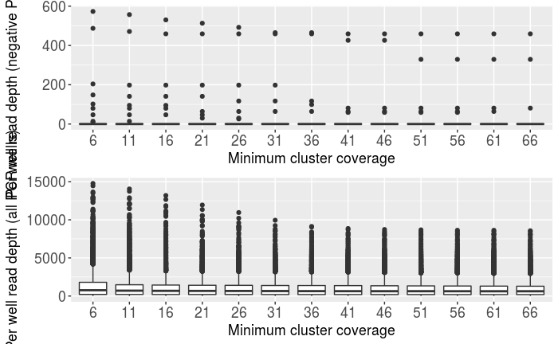

```r
### replot the above plot here for convenience
grid.draw(g.reads)
```

```r
### convert ggplots to grobs for use in gtable so that the y axes are correctly alinged
grob.all.clusters <- ggplotGrob(all.clusters)
grob.neg.clusters <- ggplotGrob(neg.clusters)
```

```
Removed 39 rows containing non-finite values (stat_boxplot).
```

```r
g.clusters <- rbind(grob.neg.clusters, grob.all.clusters , size="first")
g.clusters$widths <- unit.pmax(grob.neg.clusters$widths, grob.all.clusters$widths)
grid.newpage()
```

```r
### Write the grobbed ggplots to an svg
svg(file="diagrams/FigureS7_run2.svg",12,8)
grid.draw(g.clusters)
```

```r
dev.off()
```

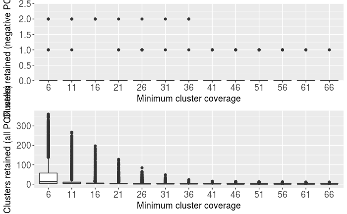

```r
### replot the above plot here for convenience
grid.draw(g.clusters)
```

### Mistagging analysis

Now that we have checked for a stable cluster size and contamination in our negatives, we should also check for mistagging in our sequencing data. To do this we have deliberately excluded certain tag combinations during PCR set up. We can now perform an analysis similar to the ones above but instead of using our tag combinations associated with samples, we use a query map with all the illegal tag combinations (84 combinations).

```r
### Read in the data and look at the number of clusters and read depth against minimum cluster size
null.read.stats<-read.csv(file="data/combined_illegal_read_stats_run2.csv", stringsAsFactors=FALSE, header=TRUE)

### Create a plot of read depth in PCR wells by minimum cluster size
null.reads<-ggplot(data = null.read.stats, aes(x=as.factor(clusters_min_cov), y=queries)) +
  geom_boxplot() +
  labs(y = "Per well read depth (all PCR wells)", x="Minimum cluster coverage") +
### make the labels more visible
  theme(axis.text = element_text(size = rel(1.2)),
         axis.title = element_text(size = rel(1.2)))

### Write the grobbed ggplots to an svg
svg(file="diagrams/FigureS8_run2.svg",12,8)
null.reads
dev.off()

### replot the above plot here for convenience
null.reads
```

[output not shown]

# Part 2: Main data analysis

In part one we decided on an a set of minimum cluster sizes for our final analysis based on three possible selection criteria. We then used these values in the [Jupyter notebook](https://github.com/HullUni-bioinformatics/Kitson_et_al_NMB/blob/master/Jupyter_notebook/OPM_NMB_main_analysis.ipynb) to run a final analysis for each minimum cluster size. Now we need to examine this output, check that negatives are clean and examine the contents of each well.

### Calculating percentage parasitism for each coverage threshold

```r
### make a list of output files
assignment.files <- paste("data/", grep("metaBEAT_transpose_.._run2", list.files(path="data/"), value = TRUE),sep="")
### read in the tables into a list we can loop across
assignment.list <- lapply(assignment.files, read.table, stringsAsFactors=FALSE, header=TRUE, sep="\t")
names(assignment.list)<-c("37 reads","52 reads","67 reads")

### make lists of % parasitism for each parasitoid
carcelia.list<-lapply(assignment.list, with, (colSums(assignment.list[[i]]["Carcelia_iliaca"] > 0)/1012)*100)
compsilura.list<-lapply(assignment.list, with, (colSums(assignment.list[[i]]["Compsilura_concinnata"] > 0)/1012)*100)

### make the lists into vectors and bind them into a data frame for exporting
carcelia <- do.call("rbind",carcelia.list)
compsilura <- do.call("rbind",compsilura.list)
parasitism.rates <- round(as.data.frame(cbind(carcelia,compsilura)),1)

### write this dataframe to a table for the manuscript
write.csv(parasitism.rates, file="data/Table1.csv")
```

### Calculating percentage sequencing success each coverage threshold

```r
### read in the combined read stats
combined.read.stats<-read.csv(file="data/combined_final_read_stats_run2.csv", stringsAsFactors = FALSE, header = TRUE)

### list the % sequencing sucess for each clustering threshold
for(i in c(37,52,67)){
print(paste("Sequencing success (all PCR wells) for minimum cluster coverage of ", i, " reads = ",
      round((sum(subset(combined.read.stats, clusters_min_cov==i, select=queries)>0)/nrow(subset(combined.read.stats, clusters_min_cov==i)))*100,1),
      "%",sep=""))
}
```

### Analysis of trimming process

First of all we need to read in the read statistics and metadata then process the data files into annoted forms suitable for plotting.

```r
### Subset the combined read stats to the cluster coverage we will finally use
final.read.stats<-subset(combined.read.stats, clusters_min_cov == "67")

### read in the sample metadata
my.plates<-read.table(file="data/sample_metadata_run2.tsv", stringsAsFactors=FALSE, header=TRUE, sep="\t")

### greedy regex to split the sample string by the underscore and leave us with a column for nest and a column for indentifier
my.plates<-cbind(my.plates, do.call(rbind, strsplit(as.character(my.plates$sample), "_|_.*_")))

### trim the plate data to the necessary columns (i.e. drop the identifier column)
my.plates<-my.plates[, c(1:5,7)]
### name the columns
colnames(my.plates)<-c("sample", "plate", "plate.numeric", "well", "strength", "template")

### process the template column into a sample type factor using a horrible ifelse statement
my.plates$type<-ifelse(my.plates$template=="neg1","Negative",
                          ifelse(my.plates$template=="neg2","Negative",
                            ifelse(my.plates$template=="DNApositive","DNApositive",
                              ifelse(my.plates$template=="PCRpositive","PCRpositive","Moth sample"))))
```

Merge the dataframes together using match and annotate the samples.

```r
### use match to add the plate data to the read data
final.read.stats$plate<-my.plates$plate[match(final.read.stats$sample, my.plates$sample)]
final.read.stats$plate.numeric<-my.plates$plate.numeric[match(final.read.stats$sample, my.plates$sample)]
final.read.stats$type<-my.plates$type[match(final.read.stats$sample,my.plates$sample)]

### set the plotting order of the plates
final.read.stats$plate<-factor(reorder(final.read.stats$plate, final.read.stats$plate.numeric))

### make sample and plate factors for faceting and ordering
final.read.stats$sample<-as.factor(final.read.stats$sample)
final.read.stats$plate<-as.factor(final.read.stats$plate)

### subset the data to only keep the numbers of reads at each stage
final.read.stats.subs<-subset(final.read.stats, select=c("sample", "total", "trimmed.total", "queries", "plate", "type"))

### melt the data into long format
final.read.stats.subs.melt<-melt(final.read.stats.subs, id.vars=c("sample", "type", "plate"))
```

Plot the read depth by plate including positives and negatives.

```r
### make the ggplot object + add the jittered dots + add the boxplots and colour them by trim level and make them a bit transparent
all.samples<-ggplot(aes(y = value, x = plate, fill = variable), data = final.read.stats.subs.melt) +
  ### plot the points
  geom_point(pch = 21, position = position_jitterdodge(), stroke = 0.2) +
  ### make the boxplot and suppress the outliers as we are plotting the points anyway
  geom_boxplot(aes(fill=variable), alpha=0.5, position = position_dodge(width = 0.85), outlier.shape = NA, lwd=0.2) +
  ### fix the axes titles
  labs(y = "Reads per PCR well", x="PCR plate") +
  scale_fill_discrete(name="Trim level",
                      breaks=c("total", "trimmed.total", "queries"),
                      labels=c("Raw reads", "Trimmed reads", "Paired reads in clusters")) +
  scale_x_discrete(expand = c(0, 0)) +
  scale_y_continuous(expand = c(0, 0), limits = c(0,65000)) +
  ### rotate the x-axis labels and resize the text for the svg
  theme(axis.text.x = element_text(size=rel(1.5), colour="black", angle=45, hjust=1),
        axis.text.y = element_text(size=rel(1.5), colour="black", angle=45, hjust=1),
        axis.title.y = element_text(size=rel(2), vjust=2),
        axis.title.x = element_text(size=rel(2), vjust=-1.3),
        legend.text = element_text(size = rel(1.5)),
        legend.title = element_text(size = rel(1.5), vjust=1),
        legend.position = "right",
        legend.key.height=unit(2, "line"),
        legend.key=element_blank(),
        legend.background = element_blank(),
        panel.background = element_blank(),
        panel.grid.major = element_blank(),
        panel.grid.minor = element_blank(),
        axis.line = element_blank(),
        panel.border = element_rect(colour = "black", fill=NA, size=1),
        plot.margin=unit(c(0.1, 0.1, 1, 1), "lines"))

### Plot above as a svg
svg(file="diagrams/trimming_summary_all_samples_run2.svg",12,8)
all.samples
dev.off()

### Plot above here for convenience
all.samples
```

Plot the read depth by plate excluding positives and negatives.

```r
### make the ggplot object + add the jittered dots + add the boxplots and colour them by trim level and make them a bit transparent
samples.only<-ggplot(aes(y = value, x = plate, fill = variable), data = subset(final.read.stats.subs.melt, final.read.stats.subs.melt$type=="Moth sample")) +
  ### plot the points
  geom_point(pch = 21, position = position_jitterdodge(), stroke = 0.2) +
  ### make the boxplot and suppress the outliers as we are plotting the points anyway
  geom_boxplot(aes(fill=variable), alpha=0.5, position = position_dodge(width = 0.85), outlier.shape = NA, lwd=0.2) +
  ### fix the axes titles
  labs(y = "Reads per PCR well", x="PCR plate") +
  scale_fill_discrete(name="Trim level",
                      breaks=c("total", "trimmed.total", "queries"),
                      labels=c("Raw reads", "Trimmed reads", "Paired reads in clusters")) +
  scale_x_discrete(expand = c(0, 0)) +
  scale_y_continuous(expand = c(0, 0), limits = c(0,65000)) +
  ### rotate the x-axis labels and resize the text for the svg
  theme(axis.text.x = element_text(size=rel(1.2), colour="black", angle=45, hjust=1),
        axis.text.y = element_text(size=rel(1.2), colour="black", angle=45, hjust=1),
        axis.title.y = element_text(size=rel(1.6), vjust=2),
        axis.title.x = element_text(size=rel(1.6), vjust=-1.3),
        legend.text = element_text(size = rel(1.4)),
        legend.title = element_text(size = rel(1.3), vjust=1),
        legend.position = "right",
        legend.key.height=unit(2, "line"),
        legend.key=element_blank(),
        legend.background = element_blank(),
        panel.background = element_blank(),
        panel.grid.major = element_blank(),
        panel.grid.minor = element_blank(),
        axis.line = element_blank(),
        panel.border = element_rect(colour = "black", fill=NA, size=0.1),
        plot.margin=unit(c(0.1, 0.1, 1, 1), "lines"))

### Plot above as a svg
svg(file="diagrams/Figure3_run2.svg",10,5)
samples.only
dev.off()

### Plot above here for convenience
samples.only
```

Plot the read depth by PCR well type

```r
### order the sample types for plotting
final.read.stats.subs.melt$type <- factor(final.read.stats.subs.melt$type,
                                levels=c("Moth sample",
                                         "DNApositive",
                                         "PCRpositive",
                                         "Negative"))

### make the ggplot object + add the jittered dots + add the boxplots and colour them by trim level and make them a bit transparent
sample.types<-ggplot(aes(y = value, x = type, fill = variable), data = final.read.stats.subs.melt) +
  ### plot the points
  geom_point(pch = 21, position = position_jitterdodge(), stroke = 0.2) +
  ### make the boxplot and suppress the outliers as we are plotting the points anyway
  geom_boxplot(aes(fill=variable), alpha=0.5, position = position_dodge(width = 0.85), outlier.shape = NA, lwd=0.2) +
  ### fix the axes titles
  labs(y = "Reads per PCR well", x="Sample type") +
  scale_fill_discrete(name="Trim level",
                      breaks=c("total", "trimmed.total", "queries"),
                      labels=c("Raw reads", "Trimmed reads", "Paired reads in clusters")) +
  scale_x_discrete(expand = c(0, 0)) +
  scale_y_continuous(expand = c(0, 0), limits = c(0,65000)) +
  ### rotate the x-axis labels and resize the text for the svg
  theme(axis.text.x = element_text(size=rel(1.2), colour="black", angle=45, hjust=1),
        axis.text.y = element_text(size=rel(1.2), colour="black", angle=45, hjust=1),
        axis.title.y = element_text(size=rel(1.6), vjust=2),
        axis.title.x = element_text(size=rel(1.6), vjust=-1.3),
        legend.text = element_text(size = rel(1.4)),
        legend.title = element_text(size = rel(1.3), vjust=1),
        legend.position = "right",
        legend.key.height=unit(2, "line"),
        legend.key=element_blank(),
        legend.background = element_blank(),
        panel.background = element_blank(),
        panel.grid.major = element_blank(),
        panel.grid.minor = element_blank(),
        axis.line = element_blank(),
        panel.border = element_rect(colour = "black", fill=NA, size=0.1),
        plot.margin=unit(c(0.1, 0.1, 1, 1), "lines"))

### Plot above as a svg
svg(file="diagrams/Figure4_run2.svg", 10, 5)
sample.types
dev.off()

### Plot above here for convenience
sample.types
```

### Trimming summary

```r
### totals and counts for text
counting<-subset(final.read.stats, final.read.stats$type=="Moth sample")

paste("PCR success (moth samples only) = ", round((1-(sum(my.plates$strength=="fail")/nrow(counting)))*100,1),"%",sep="")
paste("Sequencing success (moth samples only) = ", round((sum(counting$queries>0)/nrow(counting))*100,1),"%",sep="")

paste("Total raw reads for all samples=", sum(final.read.stats$total))
paste("Total trimmed reads for all samples=", sum(final.read.stats$trimmed.total))

paste("Maximum raw read count for moth samples =", max(counting$total))
paste("Minimum raw read count for moth samples =", min(counting$total))
paste("Mean raw read count for moth samples =", round(mean(counting$total),1))
paste("Standard deviation of raw read count for moth samples =", round(sd(counting$total),1))
paste("Total raw reads for moth samples=", sum(counting$total))

paste("Maximum trimmed read count for moth samples =", max(counting$trimmed.total))
paste("Minimum trimmed read count for moth samples =", min(counting$trimmed.total))
paste("Mean trimmed read count for moth samples =", round(mean(counting$trimmed.total),1))
paste("Standard deviation of trimmed read count for moth samples =", round(sd(counting$trimmed.total),1))
paste("Total trimmed reads for moth samples=", sum(counting$trimmed.total))

paste("Maximum retained cluster count for moth samples =", max(counting$cluster_above_thres))
paste("Minimum retained cluster count for moth samples =", min(counting$cluster_above_thres))
paste("Mean retained cluster count for moth samples =", round(mean(counting$cluster_above_thres),1))
paste("Standard deviation of retained cluster count for moth samples =",
      round(sd(counting$cluster_above_thres),1))

paste("Maximum reads per well for moth samples =", max(counting$queries))
paste("Minimum reads per well for moth samples =", min(counting$queries))
paste("Mean reads per well for moth samples =", round(mean(counting$queries),1))
paste("Standard deviation of reads per well for moth samples =", round(sd(counting$queries),1))
paste("Total clustered reads for moth samples =", sum(counting$queries))
```

### Well composition

We now need to parse the assignments into a per well composition diagram and calculate percentage parasitism.

Read in the assignment data

```r
my.assignments<-read.table(file="data/metaBEAT_transpose_run2.tsv", stringsAsFactors=FALSE, header=TRUE, sep="\t")
### because the data from metaBEAT has been transposed, the column header for column one is now a row header and needs to be replaced to make sense
colnames(my.assignments)[1]<-"sample"
```

we need to process this data quite a bit to get it annotated, formatted and into the correct order for plotting

```r
### Combine all the fungal sequences as we aren't using the correct marker to examine them properly
my.assignments$Fungi<-rowSums(my.assignments[c("Beauveria_bassiana","Penicillium","Ascomycota")])
my.assignments<-my.assignments[c(1,3:6,8,11,10)]

### Use match to add the plate data to the read data
my.assignments$plate<-my.plates$plate[match(my.assignments$sample, my.plates$sample)]
my.assignments$plate.numeric<-my.plates$plate.numeric[match(my.assignments$sample, my.plates$sample)]
my.assignments$type<-my.plates$type[match(my.assignments$sample, my.plates$sample)]

### Make sample and plate factors for faceting and ordering
my.assignments$sample<-as.factor(my.assignments$sample)
my.assignments$plate<-as.factor(my.assignments$plate)

### Total all the reads
my.assignments$total<-rowSums(my.assignments[c(2:8)])
### calculate the percentage of reads in each well that are OPM
my.assignments$percent.thau<-ifelse(my.assignments$total>0,(my.assignments$Thaumetopoea_processionea/my.assignments$total)*100,0)

### order the type for ordering the samples in the plot
my.assignments$type <- factor(my.assignments$type,
                                   levels=c("Moth sample","DNApositive","PCRpositive","Negative"))

### Reorder the wells by decreasing %OPM and increasing Carcelia and partition by type
my.assignments<-my.assignments[with(my.assignments, order(-total)), ]
my.assignments<-my.assignments[with(my.assignments, order(-percent.thau)), ]
my.assignments<-my.assignments[with(my.assignments, order((Carcelia_iliaca/total))), ]
my.assignments<-my.assignments[with(my.assignments, order(type)), ]

# Create a plotting order
my.assignments$order<-factor(seq(1, nrow(my.assignments),1))


### make a panel factor after setting the decreasing OPM order
my.assignments$panel<-as.factor(c(rep(1,times=length(my.assignments$sample)/4),
                                       rep(2,times=length(my.assignments$sample)/4),
                                       rep(3,times=length(my.assignments$sample)/4),
                                       rep(4,times=length(my.assignments$sample)/4)))

### melt the data into long format
my.assignments.melt<-melt(my.assignments, id.vars=c("sample","plate","plate.numeric","percent.thau","type","panel","order","total"))
colnames(my.assignments.melt)<-c("Sample","Plate","Plate.numeric","Percent.Thau","Type","Panel","Order","Total_reads","Species","Reads")
my.assignments.melt$Sample<-as.character(my.assignments.melt$Sample)
```

Create a separate dataframe to plot OTUs per well

```r
### Create a separate dataframe containing only samples
my.assignments.samps.only<-subset(my.assignments, type=="Moth sample")

### count the columns greater than zero and write to a new data frame - this is used for the barplot below the composition diagram
hit.hist<-data.frame(OTUs = rowSums(my.assignments.samps.only[c(2:8)] != 0), type=my.assignments.samps.only$type)
```

We need to make a colour scale to make assignments clearer. For the number of assignments we have, automatic colour selection often results in colours difficult to discern.

```r
my.colours<-brewer.pal(n=(length(unique(my.assignments.melt$Species))-1),'Paired')
my.colours[length(my.colours)+1]<-"#000000"
```

Plot the well composition and OTUs per well diagram

```r
### set up the ggplot
well.composition<-ggplot(data=my.assignments.melt, aes(x=Order, y=Reads, fill=Species)) +
  ### make it a stacked barplot and set the bars to be the same height
  geom_bar(position="fill", stat="identity") +
  ### wrap the plot by plate
  facet_wrap(~Panel, scales="free_x", nrow=4, ncol=1) +
  ### give it a percentage scale
  scale_y_continuous(labels = percent_format(), expand = c(0, 0)) +
  ### set the colours
  scale_fill_manual(name="Species",
                      values = my.colours) +
  ### add a sensible y axis label
  labs(y = "% of reads per well", x="PCR wells") +
  ### rotate the x-axis labels and resize the text for the svg
  theme(axis.text.x = element_blank(),
        #axis.text.x = element_text(size = rel(0.3), colour = "black", angle=90),
        axis.ticks.x=element_blank(),
        axis.text.y = element_text(size = rel(1.1), colour="black"),
        axis.title.y = element_text(size = rel(1), vjust=2),
        axis.title.x = element_text(size = rel(1), vjust=-1.3),
        legend.text = element_text(size = rel(1), face="italic"),
        legend.title = element_text(size = rel(1)),
        strip.text.x = element_blank(),
        strip.background=element_blank(),
        legend.position = "bottom",
        legend.background = element_blank(),
        panel.background = element_blank(),
        panel.grid.major = element_blank(),
        panel.grid.minor = element_blank(),
        panel.spacing = unit(1, "lines"),
        axis.line = element_blank(),
        panel.border = element_rect(colour = "black", fill=NA, size=0.1),
        plot.margin=unit(c(0.1, 0.1, 1, 1), "lines"))

### Make a ggplot object of our OTU counts
hist<- ggplot(hit.hist, aes(factor(reorder(OTUs, -OTUs)))) +
  geom_bar(alpha=0.5, fill="#3399ff") + labs(y = "Frequency", x="OTUs per well") +
  coord_flip() +
  ### rotate the x-axis labels and resize the text for the svg
  theme(axis.text = element_text(size = rel(1.1), colour="black"),
        axis.title.y = element_text(size = rel(1), vjust=2),
        axis.title.x = element_text(size = rel(1), vjust=-1),
        panel.grid.minor = element_blank(),
        axis.line = element_blank(),
        plot.margin=unit(c(0.1, 0.1, 1, 1), "lines"))

svg(file="diagrams/Figure8_run2.svg", width=12, height=8)
grid.arrange(well.composition, hist, heights=c(3/4, 1/4), ncol=1)
dev.off()

### Plot above here for convenience
grid.arrange(well.composition, hist, heights=c(3/4, 1/4), ncol=1)
```

### Calculating percentage parasitism

```r
### divide the number of wells containing ach parasitoid by number of wells that are not +ve or -ve to get percentage
percent.carcelia<-(colSums(my.assignments["Carcelia_iliaca"] > 0)/1012)*100
percent.compsilura<-(colSums(my.assignments["Compsilura_concinnata"] > 0)/1012)*100

paste("Percentage parasitism for Carcelia illiaca = ", round(percent.carcelia,1),"%", sep="")
paste("Percentage parasitism for Compsilura concinnata = ", round(percent.compsilura,1),"%", sep="")
```